# hwk2

Patrick Wheeler

9/21/2020

In case you want to see the arithmetic I did with inline code, here is the GitHub link to .rmb file: https://github.com/vader-coder/Stat11/blob/master/hwk2.rmd

1. Reaction time, measured from the moment the driver first sees the danger until he or she gets a foot on the brake pedal, is thought to follow a Normal model with a mean of 1.5 seconds and a standard deviation of 0.18 seconds.
1. (not to turn in) Use the 68-95-99.7 rule to draw and label the Normal model for yourself.
2. Write a sentence or two describing the reaction times.  
   The middle 95% of drivers take between 1.14 and 1.86 seconds to put their foot on the pedal.
3. What percentage of drivers have a reaction time of less than 1.25 seconds?

```r
mean = 1.5
sd = 0.18
ans_1c <- pnorm(1.25, mean=mean, sd=sd)*100
```

8.243327%  
(d) What percentage of drivers have reaction times between 1.6 and 1.8 seconds?

```r
norm_d16 <- pnorm(1.6, mean=mean, sd=sd)
norm_d18 <- pnorm(1.8, mean=mean, sd=sd)
ans_1d <- (norm_d18-norm_d16)*100
```

24.1467008%  
(e) Describe the reaction times of the slowest 1/3 of all drivers.

```r
#slowest means high reaction times
minSlowestTime <- qnorm(1/3, mean=mean, sd=sd, lower.tail=FALSE)
z_e <- (minSlowestTime-mean)/sd
```

The reaction times of the slowest 1/3 of drivers are at least 1.5775309 seconds at 0.4307273 standard deviations from the mean.  
(f) What is the interquartile range of reaction times? (hint: run pnorm(-.675))

```r
#z = (x-m)/s, x = z*s+m
q1_f = qnorm(0.25, mean=mean, sd=sd)
q2_f = qnorm(0.75, mean=mean, sd=sd)
iqr_f <- q2_f-q1_f
```

Interquartile range: 0.2428163

```r
mean_3 <- 16.3
sd_3 <- 0.2
underweight <- 100*pnorm(16, mean=mean_3, sd=sd_3)
```

6.6807201% are underweight.  
(b) Suppose that the company lawyer insists that no more than 5% of the boxes can be underweight.  
Unfortunately nothing can be done about the standard deviation of the machine’s distribution, however the mean can be altered. To what mean value should the machine be set to satisfy the lawyer and minimize waste?

```r
increment_3b <- abs(qnorm(0.05, mean=mean_3, sd=sd_3)-16)
mean_3b <- mean_3+increment_3b
underweight_check <- 100*pnorm(16, mean=mean_3b, sd=sd_3)
```

The exact mean for 5% to be underweight would be 16.3289707oz, although the company would likely round it to 16.33.

4. Consider the following four points: (200,1950), (400,1650), (600,1800), and (800,1600). The mean of the x values is m_x = 500 and the standard deviation s_x = 258.2, while the mean of the y values is m_y = 1750 and the standard deviation s_y = 158.1.
1. Use these summary statistics to calculate the z-scores for each x and y value, then calculate the correlation coefficient (r).

```r
m_x <- 500
s_x <- 258.2
m_y <- 1750
s_y <- 158.1
x <- c(200, 400, 600, 800)
y <- c(1950, 1650, 1800, 1600)
z_4x <- c()
z_4y <- c()
productSum <- 0
i <- 1
while (i <= 4) {
  z_4x <- append(z_4x, (x[i]-m_x)/s_x)
  z_4y <- append(z_4y, (y[i]-m_y)/s_y)
  productSum <- productSum+z_4x[i]*z_4y[i]
  i <- i+1
}
correlationCoef = productSum/3
```

Z-Scores for each pt (x, y):  
(200,1950): -1.16189, 1.2650221  
(400,1650): -0.3872967, -0.6325111  
(600,1800): 0.3872967, 0.3162555  
(800,1600): 1.16189, -0.9487666  
r = -0.7349083  
(b) We will rarely give much weight on to a summary statistic like the correlation coefficient for a sample size so small. In a sentence or two explain why.  
The smaller the dataset, the higher the likelyhood that any correlation is coincidental. We need a large dataset to be confident that the correlation isn’t just an accident.

5. The Decathlon is a track and field competition in which contestants participate in 10 events (long jump, 100 meter, shot put, etc). How might we compare contestants’ results across multiple events?  
   We could make a distribution for each event and compare the contestants’ results by their z-scores (how many standard deviations above the mean time or score their result was). This comparison is imperfect because it doesn’t account for the possibility that all the contestants for one event may perform better than another group does at theirs.  
   Include and run the following code chunk:

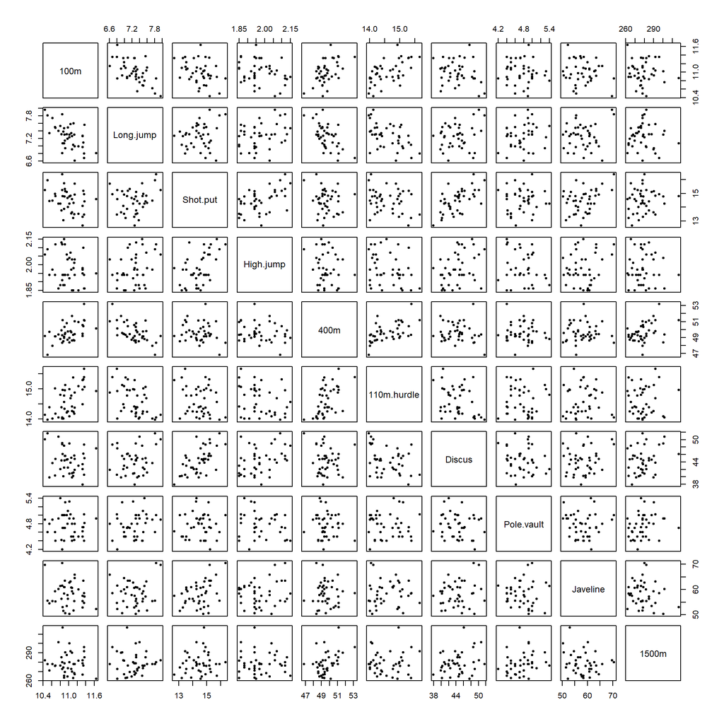

```r
pairs(decathlon[1:10],pch = 20)
```

```r
R = cor(decathlon[, 1:10])
round(R, 3)
```

```
##               100m Long.jump Shot.put High.jump   400m 110m.hurdle Discus
## 100m         1.000    -0.599   -0.356    -0.246  0.520       0.580 -0.222
## Long.jump   -0.599     1.000    0.183     0.295 -0.602      -0.505  0.194
## Shot.put    -0.356     0.183    1.000     0.489 -0.138      -0.252  0.616
## High.jump   -0.246     0.295    0.489     1.000 -0.188      -0.283  0.369
## 400m         0.520    -0.602   -0.138    -0.188  1.000       0.548 -0.118
## 110m.hurdle  0.580    -0.505   -0.252    -0.283  0.548       1.000 -0.326
## Discus      -0.222     0.194    0.616     0.369 -0.118      -0.326  1.000
## Pole.vault  -0.083     0.204    0.061    -0.156 -0.079      -0.003 -0.150
## Javeline    -0.158     0.120    0.375     0.172  0.004       0.009  0.158
## 1500m       -0.061    -0.034    0.116    -0.045  0.408       0.038  0.258
##             Pole.vault Javeline  1500m
## 100m            -0.083   -0.158 -0.061
## Long.jump        0.204    0.120 -0.034
## Shot.put         0.061    0.375  0.116
## High.jump       -0.156    0.172 -0.045
## 400m            -0.079    0.004  0.408
## 110m.hurdle     -0.003    0.009  0.038
## Discus          -0.150    0.158  0.258
## Pole.vault       1.000   -0.030  0.247
## Javeline        -0.030    1.000 -0.180
## 1500m            0.247   -0.180  1.000
```

1. Briefly describe what this plot shows and how to read it.  
   This plot consists of a collection of scatterplots. The scatterplots including an event are in its row and column, and the axis of one of these scatterplots which is parallel to the square with the event label is the axis for that event. The scatter plots comparing event ‘x’ and event ‘y’ are at the intersection between x’s column and y’s row and the intersection y’s column and x’s row. The numbers for event ‘x’ are on an outer edge of a scatterplot in its column and its row.
2. Choose two events whose results have a strong positive correlation, create a scatter plot for just these two, state the linear correlation coefficient. Why do you think these two events in particular are positively correlated?

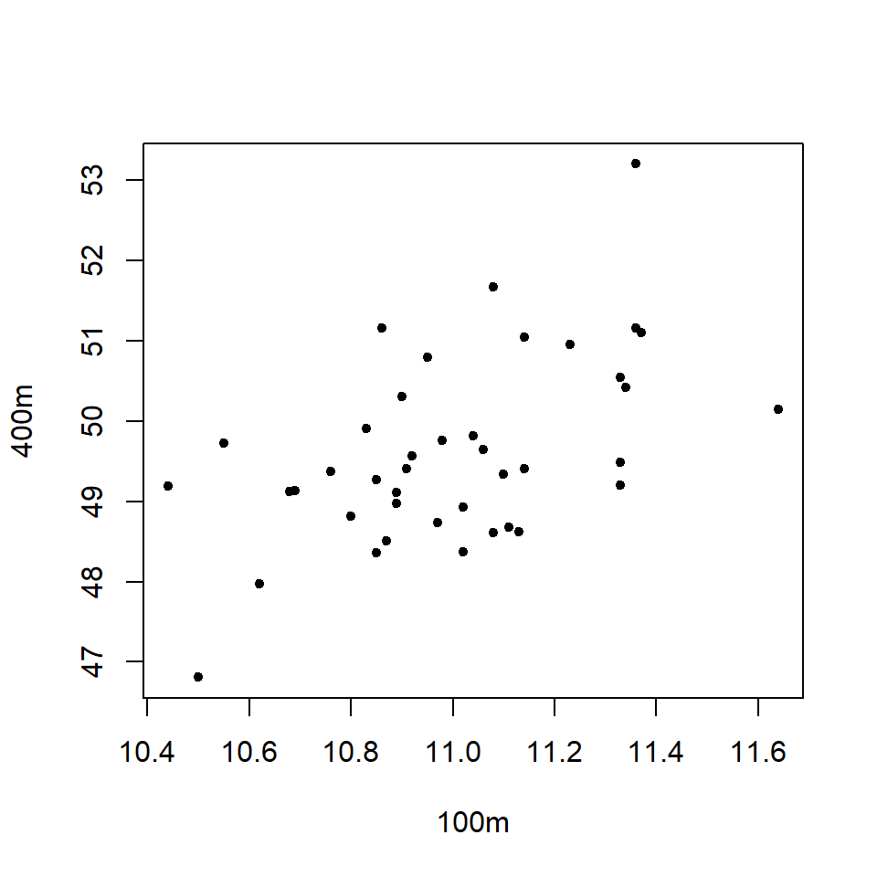

```r
#pairs(decathlon[c(1,5)], pch=20)
plot(decathlon[c(1,5)], pch=20)
```

```r
cor_b = cor(decathlon[c(1,5)])
```

r = 0.5202982  
The 100m and 400m results are positively correlated because both test runners for their speed, therefore fast sprinters will win both events.  
(c) Choose two events whose results have a strong negative correlation, create a scatterplot for just these two, state the linear correlation coefficient. Why do you think these two events in particular are negatively correlated?

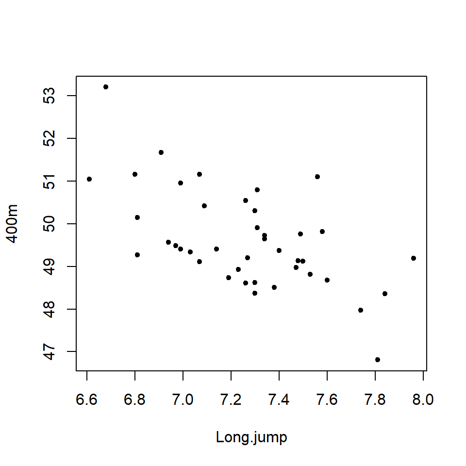

```r
plot(decathlon[c(2,5)], pch=20)
```

```r
cor_c = cor(decathlon[c(2,5)])
```